# Capture and Conquer: A Strategic Guide to Pokémon Based on Stats and Capture Rate

Based on Pokémon dataset, we will assign each Pokémon a cluster based on their stats and capture rate. The purpose of Pokémon clustering is to inform players about Pokémon combat proficiency and rarity. Players can use the result of clustering as a guide to analyze which Pokémon suits their play style, survivability chance during battle, and whether it is worth to capture.

```python
# Importing the libraries
import numpy as np
import pandas as pd
import matplotlib.pyplot as plt
import seaborn as sns
from sklearn.preprocessing import StandardScaler
from sklearn.decomposition import PCA
import scipy.stats as stats
from sklearn.cluster import KMeans
from sklearn.metrics import silhouette_score
from yellowbrick.cluster import SilhouetteVisualizer
from sklearn.datasets import make_blobs
from gap_statistic import OptimalK

pd.set_option('display.max_columns', None)
pd.set_option('display.max_rows', None)
```

```python
# graphic settings

sns.set_theme(rc={'figure.figsize':(20.7,8.27)})
sns.set_style("whitegrid")
sns.color_palette("dark")
plt.style.use("fivethirtyeight")
```

```python
import nbformat

with open('Pokemon Clustering.ipynb', 'r', encoding='utf-8') as f:
    nb = nbformat.read(f, as_version=4)

nbformat.validate(nb)
```

## Import Data

```python
df = pd.read_csv('Pokemon.csv')
```

## Data Analysis

```python
df.info()
```

```
<class 'pandas.core.frame.DataFrame'>
RangeIndex: 801 entries, 0 to 800
Data columns (total 41 columns):
 #   Column             Non-Null Count  Dtype
---  ------             --------------  -----
 0   abilities          801 non-null    object
 1   against_bug        801 non-null    float64
 2   against_dark       801 non-null    float64
 3   against_dragon     801 non-null    float64
 4   against_electric   801 non-null    float64
 5   against_fairy      801 non-null    float64
 6   against_fight      801 non-null    float64
 7   against_fire       801 non-null    float64
 8   against_flying     801 non-null    float64
 9   against_ghost      801 non-null    float64
```

[output cut: 33 more lines]

## Dataset Description

name: The English name of the Pokémon

japanese_name: The Original Japanese name of the Pokémon

pokedex_number: The entry number of the Pokémon in the National Pokedex

percentage_male: The percentage of the species that are male. Blank if the Pokémon is genderless.

type1: The Primary Type of the Pokémon

type2: The Secondary Type of the Pokémon

classification: The Classification of the Pokémon as described by the Sun and Moon Pokedex

height_m: Height of the Pokémon in metres

weight_kg: The Weight of the Pokémon in kilograms

capture_rate: Capture Rate of the Pokémon

base_egg_steps: The number of steps required to hatch an egg of the Pokémon

abilities: A stringified list of abilities that the Pokémon is capable of having

experience_growth: The Experience Growth of the Pokémon

base_happiness: Base Happiness of the Pokémon

against_?: Eighteen features that denote the amount of damage taken against an attack of a particular type

hp: The Base HP of the Pokémon

attack: The Base Attack of the Pokémon

defense: The Base Defense of the Pokémon

sp_attack: The Base Special Attack of the Pokémon

sp_defense: The Base Special Defense of the Pokémon

speed: The Base Speed of the Pokémon

generation: The numbered generation which the Pokémon was first introduced

is_legendary: Denotes if the Pokémon is legendary.

sumber: https://www.kaggle.com/datasets/rounakbanik/Pok%C3%A9mon?resource=download

```python
# data overview the first 5 Pokémon

df.head()
```

|  | abilities | against_bug | against_dark | against_dragon | against_electric | against_fairy | against_fight | against_fire | against_flying | against_ghost | against_grass | against_ground | against_ice | against_normal | against_poison | against_psychic | against_rock | against_steel | against_water | attack | base_egg_steps | base_happiness | base_total | capture_rate | classfication | defense | experience_growth | height_m | hp | … |
| --- | --- | --- | --- | --- | --- | --- | --- | --- | --- | --- | --- | --- | --- | --- | --- | --- | --- | --- | --- | --- | --- | --- | --- | --- | --- | --- | --- | --- | --- | --- |
| 0 | ['Overgrow', 'Chlorophyll'] | 1.0 | 1.0 | 1.0 | 0.5 | 0.5 | 0.5 | 2.0 | 2.0 | 1.0 | 0.25 | 1.0 | 2.0 | 1.0 | 1.0 | 2.0 | 1.0 | 1.0 | 0.5 | 49 | 5120 | 70 | 318 | 45 | Seed Pokémon | 49 | 1059860 | 0.7 | 45 | … |
| 1 | ['Overgrow', 'Chlorophyll'] | 1.0 | 1.0 | 1.0 | 0.5 | 0.5 | 0.5 | 2.0 | 2.0 | 1.0 | 0.25 | 1.0 | 2.0 | 1.0 | 1.0 | 2.0 | 1.0 | 1.0 | 0.5 | 62 | 5120 | 70 | 405 | 45 | Seed Pokémon | 63 | 1059860 | 1.0 | 60 | … |
| 2 | ['Overgrow', 'Chlorophyll'] | 1.0 | 1.0 | 1.0 | 0.5 | 0.5 | 0.5 | 2.0 | 2.0 | 1.0 | 0.25 | 1.0 | 2.0 | 1.0 | 1.0 | 2.0 | 1.0 | 1.0 | 0.5 | 100 | 5120 | 70 | 625 | 45 | Seed Pokémon | 123 | 1059860 | 2.0 | 80 | … |
| 3 | ['Blaze', 'Solar Power'] | 0.5 | 1.0 | 1.0 | 1.0 | 0.5 | 1.0 | 0.5 | 1.0 | 1.0 | 0.50 | 2.0 | 0.5 | 1.0 | 1.0 | 1.0 | 2.0 | 0.5 | 2.0 | 52 | 5120 | 70 | 309 | 45 | Lizard Pokémon | 43 | 1059860 | 0.6 | 39 | … |
| 4 | ['Blaze', 'Solar Power'] | 0.5 | 1.0 | 1.0 | 1.0 | 0.5 | 1.0 | 0.5 | 1.0 | 1.0 | 0.50 | 2.0 | 0.5 | 1.0 | 1.0 | 1.0 | 2.0 | 0.5 | 2.0 | 64 | 5120 | 70 | 405 | 45 | Flame Pokémon | 58 | 1059860 | 1.1 | 58 | … |

```python
# Descriptive statistic for numerical features

df.describe()
```

|  | against_bug | against_dark | against_dragon | against_electric | against_fairy | against_fight | against_fire | against_flying | against_ghost | against_grass | against_ground | against_ice | against_normal | against_poison | against_psychic | against_rock | against_steel | against_water | attack | base_egg_steps | base_happiness | base_total | defense | experience_growth | height_m | hp | percentage_male | pokedex_number | sp_attack | … |
| --- | --- | --- | --- | --- | --- | --- | --- | --- | --- | --- | --- | --- | --- | --- | --- | --- | --- | --- | --- | --- | --- | --- | --- | --- | --- | --- | --- | --- | --- | --- |
| count | 801.000000 | 801.000000 | 801.000000 | 801.000000 | 801.000000 | 801.000000 | 801.000000 | 801.000000 | 801.000000 | 801.000000 | 801.000000 | 801.000000 | 801.000000 | 801.000000 | 801.000000 | 801.000000 | 801.000000 | 801.000000 | 801.000000 | 801.000000 | 801.000000 | 801.000000 | 801.000000 | 8.010000e+02 | 781.000000 | 801.000000 | 703.000000 | 801.000000 | 801.000000 | … |
| mean | 0.996255 | 1.057116 | 0.968789 | 1.073970 | 1.068976 | 1.065543 | 1.135456 | 1.192884 | 0.985019 | 1.034020 | 1.098002 | 1.208177 | 0.887016 | 0.975343 | 1.005306 | 1.250312 | 0.983458 | 1.058365 | 77.857678 | 7191.011236 | 65.362047 | 428.377029 | 73.008739 | 1.054996e+06 | 1.163892 | 68.958801 | 55.155761 | 401.000000 | 71.305868 | … |
| std | 0.597248 | 0.438142 | 0.353058 | 0.654962 | 0.522167 | 0.717251 | 0.691853 | 0.604488 | 0.558256 | 0.788896 | 0.738818 | 0.735356 | 0.266106 | 0.549375 | 0.495183 | 0.697148 | 0.500117 | 0.606562 | 32.158820 | 6558.220422 | 19.598948 | 119.203577 | 30.769159 | 1.602558e+05 | 1.080326 | 26.576015 | 20.261623 | 231.373075 | 32.353826 | … |
| min | 0.250000 | 0.250000 | 0.000000 | 0.000000 | 0.250000 | 0.000000 | 0.250000 | 0.250000 | 0.000000 | 0.250000 | 0.000000 | 0.250000 | 0.000000 | 0.000000 | 0.000000 | 0.250000 | 0.250000 | 0.250000 | 5.000000 | 1280.000000 | 0.000000 | 180.000000 | 5.000000 | 6.000000e+05 | 0.100000 | 1.000000 | 0.000000 | 1.000000 | 10.000000 | … |
| 25% | 0.500000 | 1.000000 | 1.000000 | 0.500000 | 1.000000 | 0.500000 | 0.500000 | 1.000000 | 1.000000 | 0.500000 | 1.000000 | 0.500000 | 1.000000 | 0.500000 | 1.000000 | 1.000000 | 0.500000 | 0.500000 | 55.000000 | 5120.000000 | 70.000000 | 320.000000 | 50.000000 | 1.000000e+06 | 0.600000 | 50.000000 | 50.000000 | 201.000000 | 45.000000 | … |
| 50% | 1.000000 | 1.000000 | 1.000000 | 1.000000 | 1.000000 | 1.000000 | 1.000000 | 1.000000 | 1.000000 | 1.000000 | 1.000000 | 1.000000 | 1.000000 | 1.000000 | 1.000000 | 1.000000 | 1.000000 | 1.000000 | 75.000000 | 5120.000000 | 70.000000 | 435.000000 | 70.000000 | 1.000000e+06 | 1.000000 | 65.000000 | 50.000000 | 401.000000 | 65.000000 | … |
| 75% | 1.000000 | 1.000000 | 1.000000 | 1.000000 | 1.000000 | 1.000000 | 2.000000 | 1.000000 | 1.000000 | 1.000000 | 1.000000 | 2.000000 | 1.000000 | 1.000000 | 1.000000 | 2.000000 | 1.000000 | 1.000000 | 100.000000 | 6400.000000 | 70.000000 | 505.000000 | 90.000000 | 1.059860e+06 | 1.500000 | 80.000000 | 50.000000 | 601.000000 | 91.000000 | … |
| max | 4.000000 | 4.000000 | 2.000000 | 4.000000 | 4.000000 | 4.000000 | 4.000000 | 4.000000 | 4.000000 | 4.000000 | 4.000000 | 4.000000 | 1.000000 | 4.000000 | 4.000000 | 4.000000 | 4.000000 | 4.000000 | 185.000000 | 30720.000000 | 140.000000 | 780.000000 | 230.000000 | 1.640000e+06 | 14.500000 | 255.000000 | 100.000000 | 801.000000 | 194.000000 | … |

```python
# Descriptive statistic for numerical features

df.describe(include='object')
```

|  | abilities | capture_rate | classfication | japanese_name | name | type1 | type2 |
| --- | --- | --- | --- | --- | --- | --- | --- |
| count | 801 | 801 | 801 | 801 | 801 | 801 | 417 |
| unique | 482 | 34 | 588 | 801 | 801 | 18 | 18 |
| top | ['Levitate'] | 45 | Dragon Pokémon | Fushigidaneフシギダネ | Bulbasaur | water | flying |
| freq | 29 | 250 | 8 | 1 | 1 | 114 | 95 |

There are 34 numerical features and 7 categorical features in Pokémon dataset. In this clustering, we will only select relevant features to Pokémon combat capability and capture rate.

By focusing on stats and capture rates, the clustering analysis will remains clear and straightforward, avoiding the complexity that might arise from incorporating too many variables. Clusters based on stats and capture rates are easier to interpret by players, providing clear insights into different categories of Pokémon.

Stats determine a Pokémon’s effectiveness in battles, and capture rates affect how easily players can obtain these Pokémon, both of which are central to gameplay strategy. Players often make decisions based on these two features when forming teams and planning captures, making them highly relevant for clustering.

## Duplicate Data Handling

The unique values in Pokémon name is 801, which is the same as total rows in the dataset. Hence all rows in Pokémon dataset is unique. Therefore, it should be no duplicate rows in the dataset.

```python
df.duplicated().sum()
```

```
0
```

There is no duplicate data in the Pokémon dataset.

## Feature Selection

As explained before, not all features directly influence Pokémon combat capability and capture rate, such as base_happiness, classification, and base_egg_steps. In order to make cluster focused on Pokémon combat proficiency and capture rate, some relevant features will be selected for further analysis:

- hp
- attack
- sp_attack
- defense
- sp_defense
- speed
- capture_rate

```python
# use relevant features for clustering

selected_features = ['hp', 'attack', 'defense', 'sp_attack', 'sp_defense', 'speed', 'capture_rate']
pokemon_df = df[selected_features]
```

```python
# check data type of relevant features

pokemon_df.info()
```

```
<class 'pandas.core.frame.DataFrame'>
RangeIndex: 801 entries, 0 to 800
Data columns (total 7 columns):
 #   Column        Non-Null Count  Dtype
---  ------        --------------  -----
 0   hp            801 non-null    int64
 1   attack        801 non-null    int64
 2   defense       801 non-null    int64
 3   sp_attack     801 non-null    int64
 4   sp_defense    801 non-null    int64
 5   speed         801 non-null    int64
 6   capture_rate  801 non-null    object
dtypes: int64(6), object(1)
memory usage: 43.9+ KB
```

```python
pokemon_df.describe()
```

|  | hp | attack | defense | sp_attack | sp_defense | speed |
| --- | --- | --- | --- | --- | --- | --- |
| count | 801.000000 | 801.000000 | 801.000000 | 801.000000 | 801.000000 | 801.000000 |
| mean | 68.958801 | 77.857678 | 73.008739 | 71.305868 | 70.911361 | 66.334582 |
| std | 26.576015 | 32.158820 | 30.769159 | 32.353826 | 27.942501 | 28.907662 |
| min | 1.000000 | 5.000000 | 5.000000 | 10.000000 | 20.000000 | 5.000000 |
| 25% | 50.000000 | 55.000000 | 50.000000 | 45.000000 | 50.000000 | 45.000000 |
| 50% | 65.000000 | 75.000000 | 70.000000 | 65.000000 | 66.000000 | 65.000000 |
| 75% | 80.000000 | 100.000000 | 90.000000 | 91.000000 | 90.000000 | 85.000000 |
| max | 255.000000 | 185.000000 | 230.000000 | 194.000000 | 230.000000 | 180.000000 |

```python
pokemon_df.describe(include=object)
```

|  | capture_rate |
| --- | --- |
| count | 801 |
| unique | 34 |
| top | 45 |
| freq | 250 |

Each features have similar mean and median, which means that their distribution is more like a normal distribution.

We will inspect these further in outlier handling section.

## Missing Value Handling

```python
pokemon_df.isna().sum()
```

```
hp              0
attack          0
defense         0
sp_attack       0
sp_defense      0
speed           0
capture_rate    0
dtype: int64
```

Even though the initial checking of missing value shows no missing values in all features, we will check thoroughly whether the dataset is not have "hidden" missing value, such as unknown or invalid data, by checking them through value counts for each features.

```python
for col in pokemon_df.columns:
    print(f"============= {col} =================")
    display(pokemon_df[col].value_counts())
    print()
```

```
============= hp =================
```

```
hp
60     68
70     55
50     54
75     44
65     44
45     42
40     41
80     38
55     37
100    28
90     28
95     22
85     22
35     16
```

[output cut: 86 more lines]

```
============= attack =================
```

```
attack
100    38
60     35
65     35
55     35
75     34
50     34
80     33
70     32
85     32
90     27
45     27
95     25
40     23
120    22
```

[output cut: 101 more lines]

```
============= defense =================
```

```
defense
50     51
70     49
60     46
80     41
40     39
90     33
65     33
45     32
55     30
100    29
95     29
85     27
75     27
35     24
```

[output cut: 96 more lines]

```
============= sp_attack =================
```

```
sp_attack
40     52
60     48
65     43
50     42
55     38
45     34
70     30
95     30
35     29
30     28
80     26
100    26
85     25
90     23
```

[output cut: 98 more lines]

```
============= sp_defense =================
```

```
sp_defense
50     53
60     44
65     42
55     42
70     41
80     41
75     39
45     38
40     33
90     32
95     31
85     28
100    25
30     22
```

[output cut: 84 more lines]

```
============= speed =================
```

```
speed
60     46
50     43
65     38
45     36
70     36
30     35
40     34
80     29
55     28
85     28
90     27
100    26
35     26
95     21
```

[output cut: 100 more lines]

```
============= capture_rate =================
```

```
capture_rate
45                          250
190                          75
255                          69
75                           61
3                            58
120                          55
60                           50
90                           38
30                           20
200                          19
225                          15
25                           13
180                          11
50                            7
```

[output cut: 21 more lines]

After looking through all unique values in each features, hp and capture_rate need to be analyzed further. On the other hand, the other features have no missing or invalid value.

### hp feature

There is 1 unique value in hp feature that only have 1 HP, which is quite suspicious. We should check the name of Pokémon to confirm whether this value is valid.

```python
df[df['hp'] == 1]
```

|  | abilities | against_bug | against_dark | against_dragon | against_electric | against_fairy | against_fight | against_fire | against_flying | against_ghost | against_grass | against_ground | against_ice | against_normal | against_poison | against_psychic | against_rock | against_steel | against_water | attack | base_egg_steps | base_happiness | base_total | capture_rate | classfication | defense | experience_growth | height_m | hp | … |
| --- | --- | --- | --- | --- | --- | --- | --- | --- | --- | --- | --- | --- | --- | --- | --- | --- | --- | --- | --- | --- | --- | --- | --- | --- | --- | --- | --- | --- | --- | --- |
| 291 | ['Wonder Guard'] | 0.5 | 2.0 | 1.0 | 1.0 | 1.0 | 0.0 | 2.0 | 2.0 | 2.0 | 0.5 | 0.5 | 1.0 | 0.0 | 0.5 | 1.0 | 2.0 | 1.0 | 1.0 | 90 | 3840 | 70 | 236 | 45 | Shed Pokémon | 45 | 600000 | 0.8 | 1 | … |

Pokémon that has 1 HP is Shedinja. After checking through bulbagarden website, it is true that Shedinja only have 1 HP. Hence, this value is not categorized as missing or invalid value.

https://bulbapedia.bulbagarden.net/wiki/Shedinja_(Pok%C3%A9mon)#1_HP_trivia

### capture_rate feature

Capture rate feature is still in categorical data type.

Based on the unique values above, capture rate supposed to be in numerical (int) data type. There is one row that have value: '30 (Meteorite)255 (Core)', which is a string. We will check which Pokémon it is.

```python
df[df['capture_rate'] == '30 (Meteorite)255 (Core)']
```

|  | abilities | against_bug | against_dark | against_dragon | against_electric | against_fairy | against_fight | against_fire | against_flying | against_ghost | against_grass | against_ground | against_ice | against_normal | against_poison | against_psychic | against_rock | against_steel | against_water | attack | base_egg_steps | base_happiness | base_total | capture_rate | classfication | defense | experience_growth | height_m | hp | … |
| --- | --- | --- | --- | --- | --- | --- | --- | --- | --- | --- | --- | --- | --- | --- | --- | --- | --- | --- | --- | --- | --- | --- | --- | --- | --- | --- | --- | --- | --- | --- |
| 773 | ['Shields Down'] | 0.5 | 1.0 | 1.0 | 2.0 | 1.0 | 1.0 | 0.5 | 0.5 | 1.0 | 1.0 | 0.0 | 2.0 | 0.5 | 0.5 | 1.0 | 2.0 | 2.0 | 2.0 | 100 | 6400 | 70 | 500 | 30 (Meteorite)255 (Core) | Meteor Pokémon | 60 | 1059860 | 0.3 | 60 | … |

Pokémon that has capture rate of 30 (Meteorite)255 (Core) is Minior. After checking through bulbagarden website, Minior is a Pokémon that have two forms (Meteor and Core).

If Minior is in Meteor form, its capture rate will be 30. On the other hand, if Minior is in Core form, its capture rate will be 255.

After comparing to the stats in dataset and website, Minior in the Pokémon dataset is in Core form.

As we know the actual value of its capture rate (255), we will impute this value to replace '30 (Meteorite)255 (Core)'.

Median or mode impute to handle missing or invalid value is not used, since we have the actual data from the website.

https://bulbapedia.bulbagarden.net/wiki/Minior_(Pok%C3%A9mon)#Meteor_Form

```python
# replace 30 (Meteorite)255 (Core)' to 255

pokemon_df = pokemon_df.copy()

pokemon_df.loc[pokemon_df['capture_rate'] == '30 (Meteorite)255 (Core)', 'capture_rate'] = '255'
```

```python
# check whether the value of 30 (Meteorite)255 (Core)' is already replaced by 255

print(f"============= capture_rate =================")
display(pokemon_df['capture_rate'].value_counts())
print()
```

```
============= capture_rate =================
```

```
capture_rate
45     250
190     75
255     70
75      61
3       58
120     55
60      50
90      38
30      20
200     19
225     15
25      13
180     11
50       7
```

[output cut: 20 more lines]

The value of 255 has increased from 69 to 70 after value replacement. Hence the data is already in the same format.

There is no more missing or invalid values found in the dataset.

## Feature Encoding

There is still one problem in the dataset. Capture_rate feature still in categorical data type. Hence, this feature will be encoded to numerical values.

```python
# feature encoding to numerical (int) data type

pokemon_df['capture_rate'] = pokemon_df['capture_rate'].astype(int)
```

Direct feature encoding to numerical values is chosen instead of the other feature encoding techniques like One-Hot Encoding or Label Encoding. This is because capture rate feature has already contained actual numerical values of Pokémon capture rate. This feature is in categorical data type because there is one special Pokémon (Minior) that have 2 capture rates depending on its form.

By doing direct encoding to numerical (integer) data types, the feature will represent actual values of Pokémon capture rate rather than encode it to specific number such as mean encoding.

```python
# check data type of capture_rate after feature encoding

pokemon_df.info()
```

```
<class 'pandas.core.frame.DataFrame'>
RangeIndex: 801 entries, 0 to 800
Data columns (total 7 columns):
 #   Column        Non-Null Count  Dtype
---  ------        --------------  -----
 0   hp            801 non-null    int64
 1   attack        801 non-null    int64
 2   defense       801 non-null    int64
 3   sp_attack     801 non-null    int64
 4   sp_defense    801 non-null    int64
 5   speed         801 non-null    int64
 6   capture_rate  801 non-null    int64
dtypes: int64(7)
memory usage: 43.9 KB
```

capture_rate feature has been encoded from categorical data type to numerical data type. By using capture_rate in numerical data type, this feature now can be used in clustering model.

## Correlation Analysis

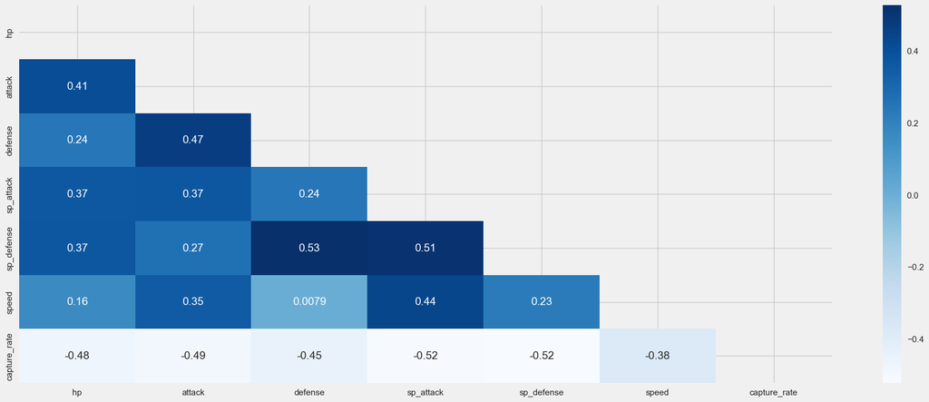

```python
# heatmap correlation

corr = pokemon_df.corr()

mask = np.triu(np.ones_like(corr, dtype=bool))

sns.heatmap(corr, cmap = 'Blues', annot=True, mask = mask)
plt.show()
```

The capture rate is inversely correlated to all other stats, meaning that the stronger the Pokémon (HP, attack, defense, special attack, special defense, and speed), the lower the capture rate. This aligns with game balance where more powerful Pokémon are harder to catch, adding challenge and strategy to the game. This ensures a balanced gameplay experience where powerful Pokémon require more effort to obtain.

## Outlier Handlling

```python
# function to check histogram, distribution plot, and boxplot

def check_plot(df, variable):
    # check distribution plot from variable in df.

    # figure size and title
    plt.figure(figsize=(16, 4))
    plt.suptitle(f' Outlier Analysis for {variable} feature', fontsize=16, y=1.05)

    # histogram
    plt.subplot(1, 3, 1)
    sns.histplot(df[variable], bins = 30)
    plt.title('Histogram')

    # distribution (Q-Q) plot
    plt.subplot(1, 3, 2)
    stats.probplot(df[variable], dist="norm", plot=plt)
    plt.ylabel('Variable quantiles')

    # box plot
    plt.subplot(1, 3, 3)
    sns.boxplot(y=df[variable])
    plt.title('Boxplot')

    plt.show()
```

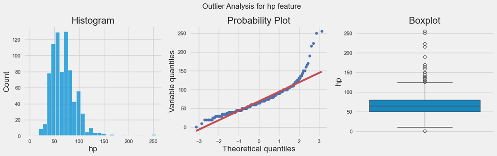

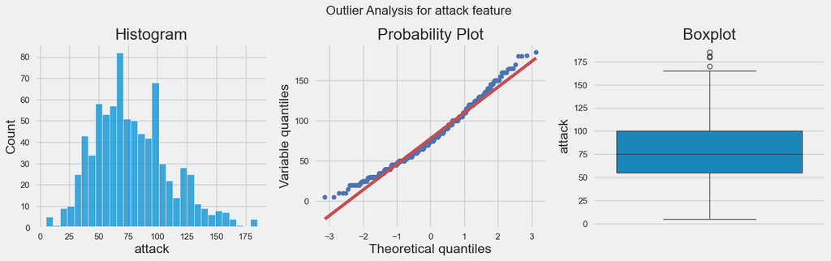

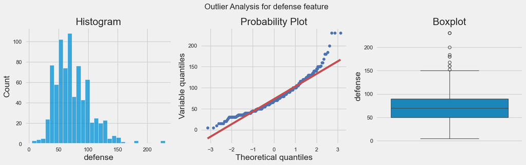

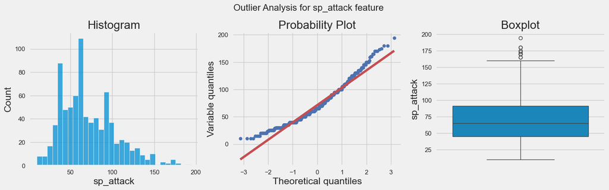

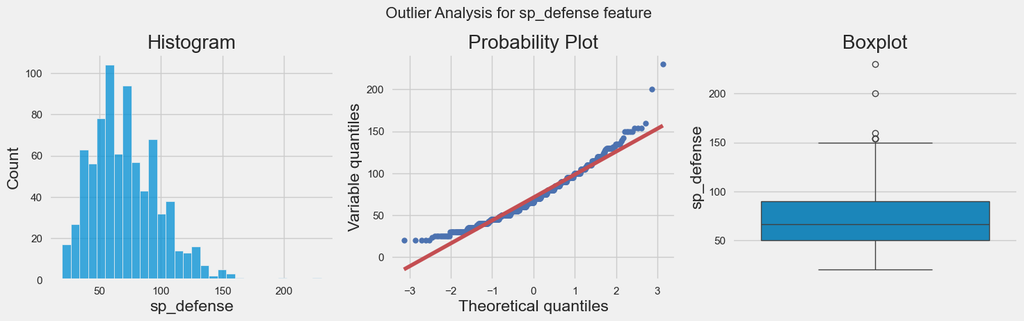

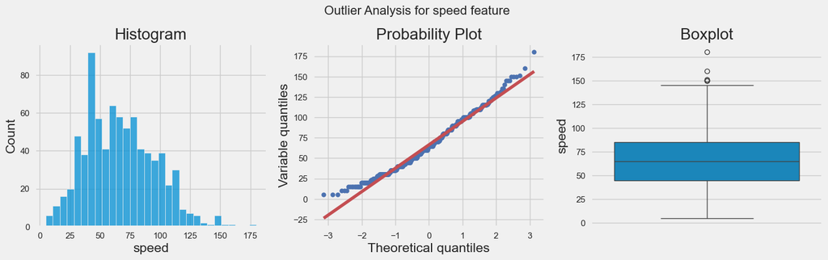

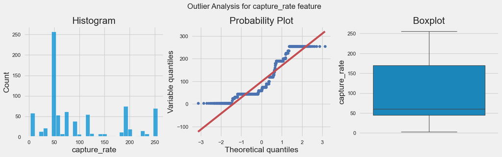

```python
# plot looping for distribution analysis each features

for col in selected_features:
    check_plot(pokemon_df, col)
```

All features, except capture_rate, have outliers at their maximum values, especially hp, defense, and sp_defense that have extreme high outliers value. IQR will be checked for each features for outlier handling.

```python
# function to check upper IQR and lower IQR from columns

def find_outlier_boundary(df, variable):

    IQR = df[variable].quantile(0.75) - df[variable].quantile(0.25)

    lower_boundary = df[variable].quantile(0.25) - (IQR * 1.5)
    upper_boundary = df[variable].quantile(0.75) + (IQR * 1.5)

    return upper_boundary, lower_boundary
```

```python
# dataframe to summarize IQR compared to minimum and maximum value for each columns

pd.DataFrame(data = {'Upper_IQR': [find_outlier_boundary(pokemon_df, col)[0] for col in selected_features],
                     'Maximum': [pokemon_df[col].max() for col in selected_features],
                     'Lower_IQR': [find_outlier_boundary(pokemon_df, col)[1]  for col in selected_features],
                     'Minimum': [pokemon_df[col].min() for col in selected_features]},
             index = [col for col in selected_features])
```

|  | Upper_IQR | Maximum | Lower_IQR | Minimum |
| --- | --- | --- | --- | --- |
| hp | 125.0 | 255 | 5.0 | 1 |
| attack | 167.5 | 185 | -12.5 | 5 |
| defense | 150.0 | 230 | -10.0 | 5 |
| sp_attack | 160.0 | 194 | -24.0 | 10 |
| sp_defense | 150.0 | 230 | -10.0 | 20 |
| speed | 145.0 | 180 | -15.0 | 5 |
| capture_rate | 357.5 | 255 | -142.5 | 3 |

All features, except hp, have negative values in lower IQR. However, all features, except hp, have their minimum value greater than its lower IQR. Hence, only hp (with 1 hp value as minimum) will be changed to its lower IQR (5). The other features are still in their IQR.

However, all features, except capture_rate, have their maximum values higher than its upper IQR. Hence, the values that is higher than upper IQR will be replaced to its upper IQR, so the features will be more likely to have normal distribution for clustering.

```python
# replace the outliers with upper and lower IQR

for col in selected_features:
    Population_upper_limit, Population_lower_limit = find_outlier_boundary(pokemon_df, col)

    pokemon_df[col]= np.where(pokemon_df[col] > Population_upper_limit, Population_upper_limit,
                       np.where(pokemon_df[col] < Population_lower_limit, Population_lower_limit, pokemon_df[col]))
```

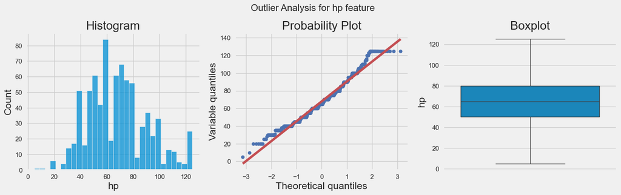

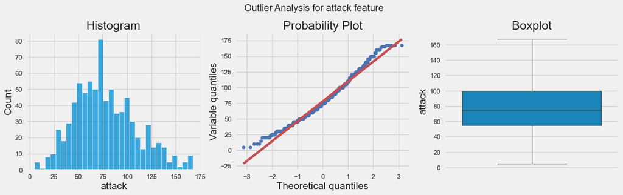

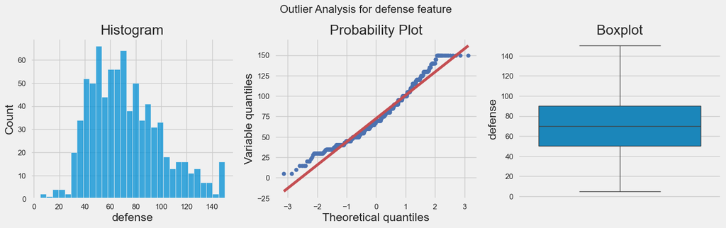

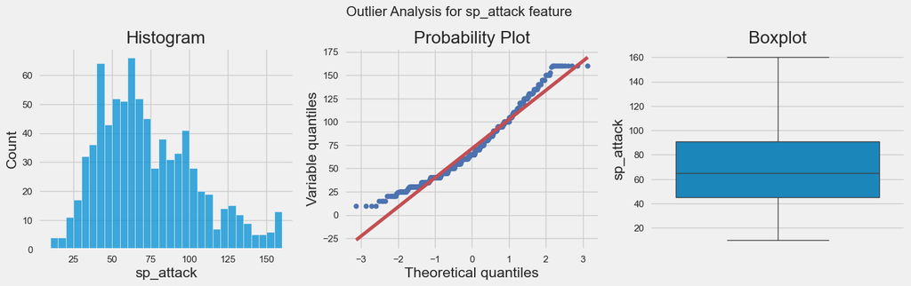

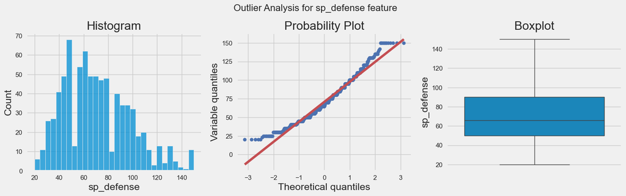

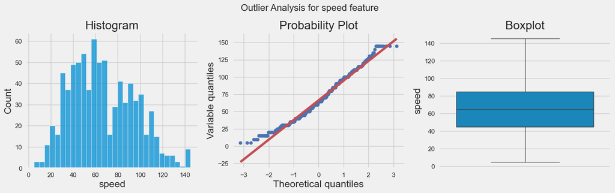

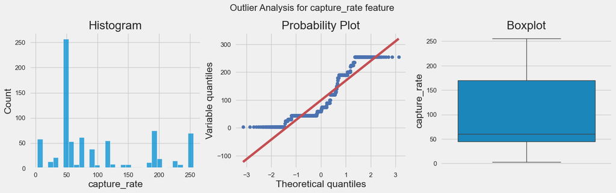

```python
# plot looping for distribution analysis after outlier treatment in features

for col in selected_features:
    check_plot(pokemon_df, col)
```

K-means clustering algorithm will more likely to perform better after outlier handling, since the algorithm is heavily affected by mean of distance from each data point to its centroid.

## Feature Scaling

```python
# feature standardization to ensure each features have similar scales

scaler = StandardScaler()
scaled_features = scaler.fit_transform(pokemon_df)
```

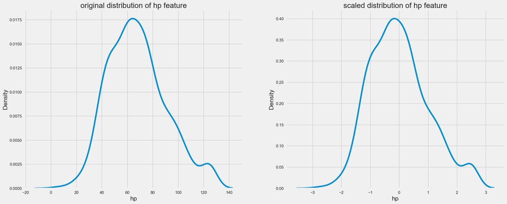

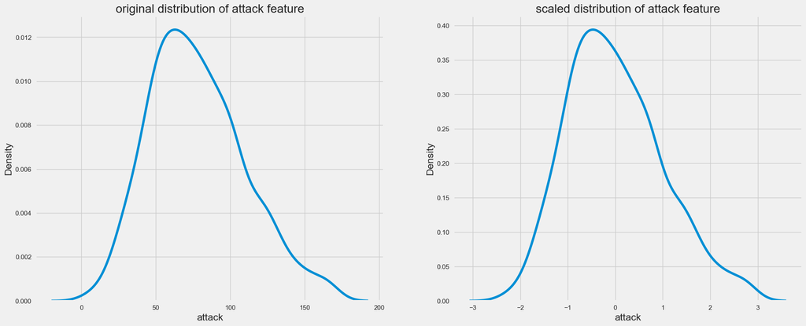

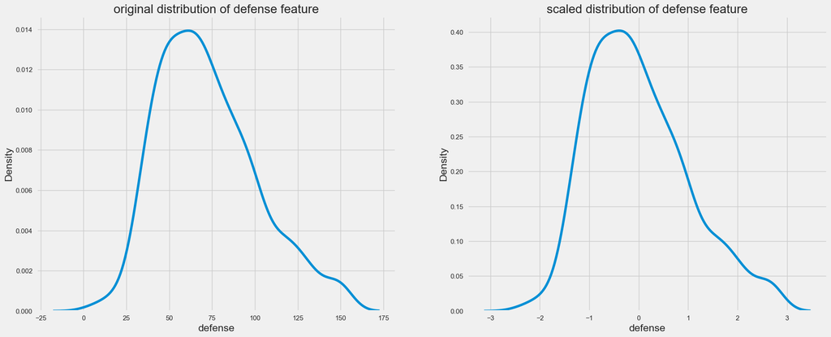

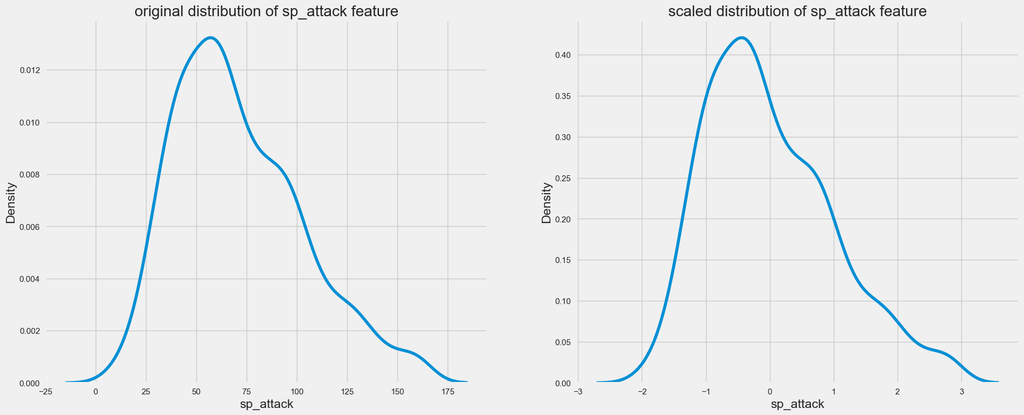

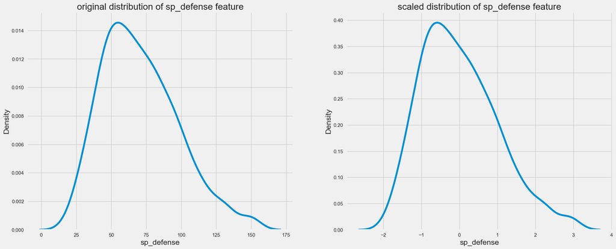

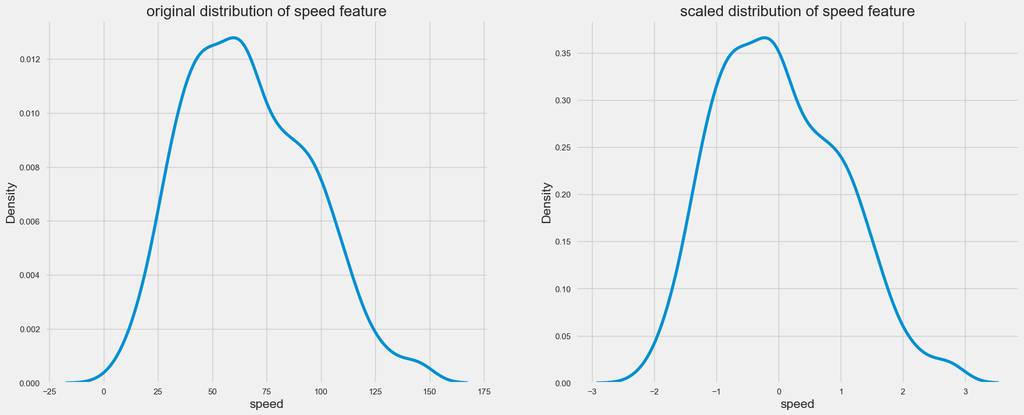

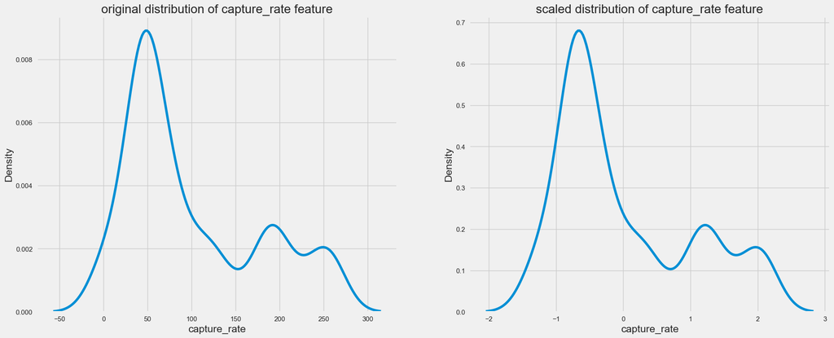

```python
# comparing each features before and after feature scaling

scaled_features = pd.DataFrame(scaled_features,columns= selected_features)

for col in selected_features:
    plt.subplot(121)
    sns.kdeplot(pokemon_df[col])
    plt.title(f'original distribution of {col} feature')

    plt.subplot(122)
    sns.kdeplot(scaled_features[col])
    plt.title(f'scaled distribution of {col} feature')
    plt.show()
```

## Evaluate optimal cluster number by Elbow method, Silhoutte Score, and Gap Statistic method

To obtain the optimal number of clusters, we will do evaluation with Elbow method, Silhoutte Score, and Gap Statistic method.

### Elbow Method

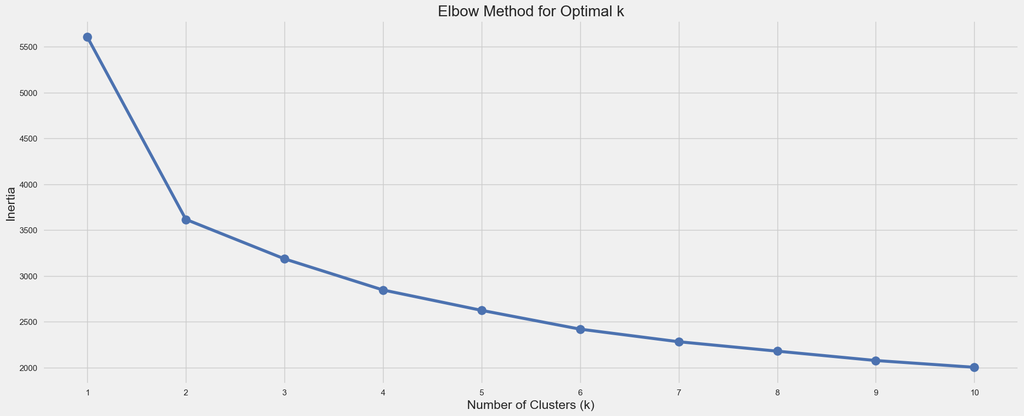

```python
# Elbow Method for optimal k (cluster number)

inertia = []
for n_clusters in range(1, 11):
    kmeans = KMeans(n_clusters=n_clusters, init='k-means++', max_iter=300, n_init=10, random_state=42)
    kmeans.fit(scaled_features)
    inertia.append(kmeans.inertia_)

# Plotting the Elbow Curve

plt.plot(range(1, 11), inertia, marker='o', markersize= 12, linestyle='-', color='b')
plt.title('Elbow Method for Optimal k')
plt.xlabel('Number of Clusters (k)')
plt.ylabel('Inertia')
plt.xticks(range(1, 11))
plt.grid(True)
plt.show()
```

```python
# input elbow analysis results to dataframe

inertia_decrease = pd.Series(inertia) - pd.Series(inertia).shift(-1) / pd.Series(inertia) * 100 #untuk melihat pengurangan inertia

# Calculate percentage decrease

inertia_values = pd.Series(inertia)
percentage_decrease = ((inertia_values.shift(1) - inertia_values) / inertia_values.shift(1)) * 100

# present elbow analysis results in dataframe

inertia_table = pd.concat([inertia_decrease, percentage_decrease], axis=1)
inertia_table.reset_index(inplace=True)
inertia_table.columns = ['Cluster Number', 'Inertia Decrease', 'Percentage Inertia Decrease (%)']
inertia_table['Cluster Number'] += 1

inertia_table
```

|  | Cluster Number | Inertia Decrease | Percentage Inertia Decrease (%) |
| --- | --- | --- | --- |
| 0 | 1 | 5542.502275 | NaN |
| 1 | 2 | 3528.284972 | 35.502275 |
| 2 | 3 | 3096.801700 | 11.897506 |
| 3 | 4 | 2753.844373 | 10.674157 |
| 4 | 5 | 2531.605107 | 7.809094 |
| 5 | 6 | 2324.300148 | 7.819386 |
| 6 | 7 | 2185.794044 | 5.678369 |
| 7 | 8 | 2083.075392 | 4.510522 |
| 8 | 9 | 1979.783097 | 4.689671 |
| 9 | 10 | NaN | 3.556494 |

Based on elbow analysis depicted in graph and table, after k = 4, there is no significant decrease in inertia (below 10% of inertia decrease after cluster number = 4). Hence, the optimal number of cluster from elbow analysis is 4.